# Course: Introduction to open data science

Emma Haapa

c

# Week 2: Regression and model validation

The [data](http://www.helsinki.fi/~kvehkala/JYTmooc/JYTOPKYS3-data.txt) we wrangled and analyzed this week is called JYTOPKYS3 by Kimmo Vehkalahti, which I named “learning14” for the course of the initial wrangling assignments. The number of observations in the data is 183 and there are in total 66 variables.

The variables, essentially the statements or questions in the questionnaire, are coded in short sections of letters and numbers, for example “SU08” = “I tend to read very little beyond what is actually required to pass”, “D06” = “I look at the evidence carefully and try to reach my own conclusion about what I’m studying” and “ST01” = “I manage to find conditions for studying which allow me to get on with my work easily”, the initials of which in turn correspond to their function in measuring the student’s deep, surface or strategic inclination towards learning. In other words, the combinations of variables are meters which measure the dimensions of deep, strategic and surface learning.

There are also background variables in the data, such as “gender” and “age”, and variables that measure more general things associated with learning, succeeding in the learning process and how much time the student spends studying. The study was conducted in 2014 as an international study project with funding from Opettajien Akatemia (see this [link](http://www.helsinki.fi/~kvehkala/JYTmooc/JYTOPKYS3-meta.txt) for further clarification).

The structure of the data can be further explored by using the str()- and head()-functions in R.

```r
str(learning2014)
```

```
## 'data.frame':    166 obs. of  7 variables:
##  $ gender  : Factor w/ 2 levels "F","M": 1 2 1 2 2 1 2 1 2 1 ...
##  $ age     : int  53 55 49 53 49 38 50 37 37 42 ...
##  $ attitude: num  3.7 3.1 2.5 3.5 3.7 3.8 3.5 2.9 3.8 2.1 ...
##  $ deep    : num  3.58 2.92 3.5 3.5 3.67 ...
##  $ stra    : num  3.38 2.75 3.62 3.12 3.62 ...
##  $ surf    : num  2.58 3.17 2.25 2.25 2.83 ...
##  $ points  : int  25 12 24 10 22 21 21 31 24 26 ...
```

```r
head(learning2014)
```

```
##   gender age attitude     deep  stra     surf points
## 1      F  53      3.7 3.583333 3.375 2.583333     25
## 2      M  55      3.1 2.916667 2.750 3.166667     12
## 3      F  49      2.5 3.500000 3.625 2.250000     24
## 4      M  53      3.5 3.500000 3.125 2.250000     10
## 5      M  49      3.7 3.666667 3.625 2.833333     22
## 6      F  38      3.8 4.750000 3.625 2.416667     21
```

of which the first shows that the variables ‘age’ and ‘points’ only get integer values, whereas ‘attitude’, ‘deep’, ‘stra’ and ‘surf’ get numerical values. The gender variable is a 2-level factor, with the values 1 or 2, 1 being “F” or ‘female’ and 2 being “M” or ‘male’. The latter, in turn, shows the first parts of the vectors in the data, in this case, the first 6 observations, in detail (all of the variables’ values of this observation).

### The relationships between the variables

First, as an example, I will follow the idea in the DataCamp exercise and draw a plot of attitude versus exam points with gender specifying the plots. Also a regression line is added to the plots, one for both genders (if gender is male, the line is blue and if female, the line is red.) The regression line is fitted using the least squares approach.

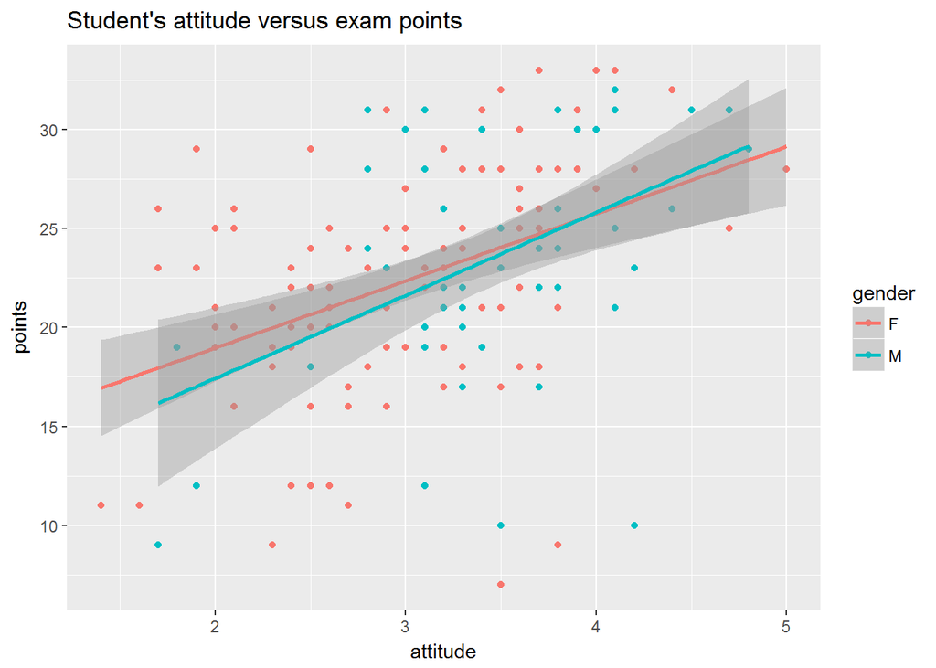

I attempted to make a similar scatter plot out of two other variables in the learning2014 data, for learning’s sake. I decided to choose variables “deep” and “points”, to see if the student’s deep leaning skills are in some kind of connection or loosely said, correlation, with each other.

[figure not shown]

[figure not shown]

From this I concluded, that there seems to be more connection with a students strategic learning skills and their exam points, at least more so than with their deep leaning skills. The regression line in this case, is an ascending line i. e. the slope of the line is positive. This tends to say that the more the student is inclined towads strategic learning, the bigger number of points they seem to score from an exam. However, these are just initial observations, and have little if nothing to do with actual statistical analysis - but based on these ponderings and inclinations I would, as a statistician, try to establish my further work on this notion.

The following illustrates the simple regression between a few of the variables:

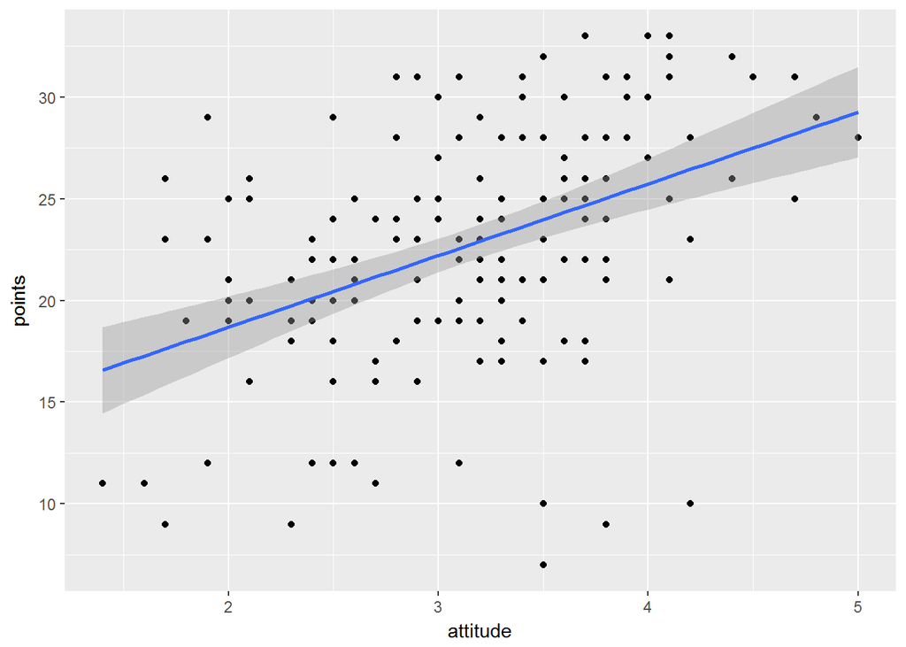

```
##
## Call:
## lm(formula = points ~ attitude, data = learning2014)
##
## Residuals:
##      Min       1Q   Median       3Q      Max
## -16.9763  -3.2119   0.4339   4.1534  10.6645
##
## Coefficients:
##             Estimate Std. Error t value Pr(>|t|)
## (Intercept)  11.6372     1.8303   6.358 1.95e-09 ***
## attitude      3.5255     0.5674   6.214 4.12e-09 ***
## ---
## Signif. codes:  0 '***' 0.001 '**' 0.01 '*' 0.05 '.' 0.1 ' ' 1
##
## Residual standard error: 5.32 on 164 degrees of freedom
## Multiple R-squared:  0.1906, Adjusted R-squared:  0.1856
## F-statistic: 38.61 on 1 and 164 DF,  p-value: 4.119e-09
```

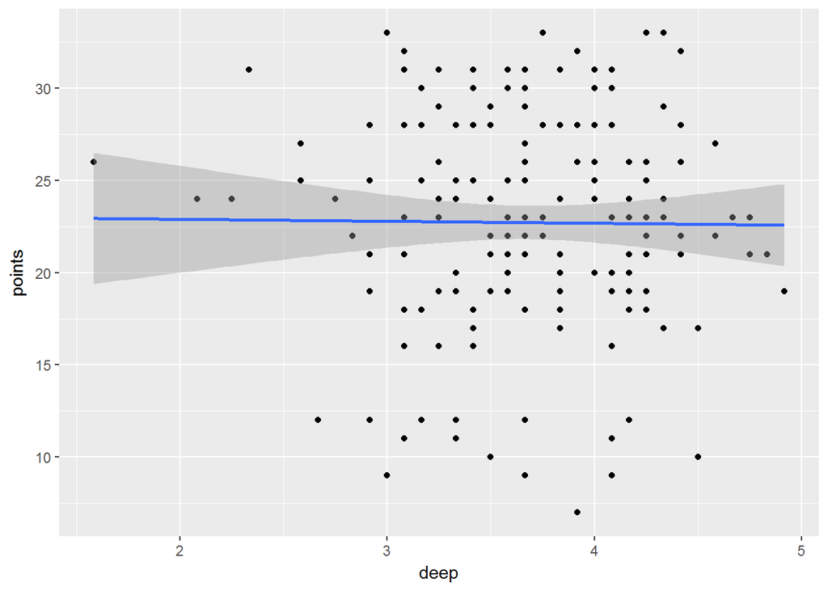

```
##
## Call:
## lm(formula = points ~ deep, data = learning2014)
##
## Residuals:
##      Min       1Q   Median       3Q      Max
## -15.6913  -3.6935   0.2862   4.9957  10.3537
##
## Coefficients:
##             Estimate Std. Error t value Pr(>|t|)
## (Intercept)  23.1141     3.0908   7.478 4.31e-12 ***
## deep         -0.1080     0.8306  -0.130    0.897
## ---
## Signif. codes:  0 '***' 0.001 '**' 0.01 '*' 0.05 '.' 0.1 ' ' 1
##
## Residual standard error: 5.913 on 164 degrees of freedom
## Multiple R-squared:  0.000103,   Adjusted R-squared:  -0.005994
## F-statistic: 0.01689 on 1 and 164 DF,  p-value: 0.8967
```

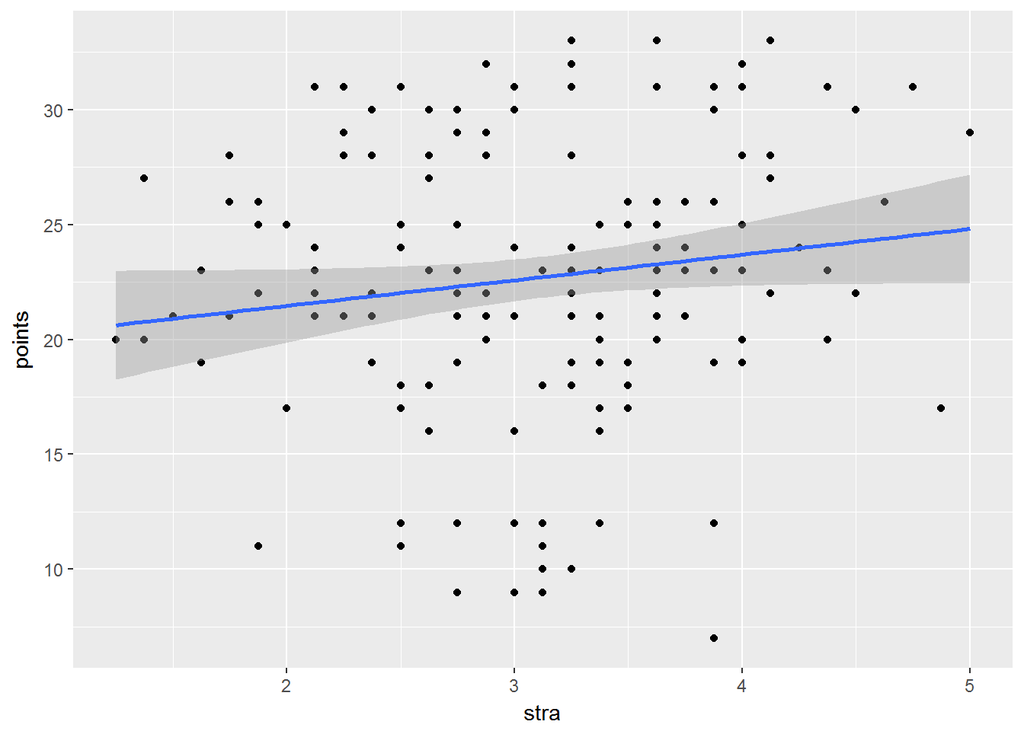

```
##
## Call:
## lm(formula = points ~ stra, data = learning2014)
##
## Residuals:
##      Min       1Q   Median       3Q      Max
## -16.5581  -3.8198   0.1042   4.3024  10.1394
##
## Coefficients:
##             Estimate Std. Error t value Pr(>|t|)
## (Intercept)   19.233      1.897  10.141   <2e-16 ***
## stra           1.116      0.590   1.892   0.0603 .
## ---
## Signif. codes:  0 '***' 0.001 '**' 0.01 '*' 0.05 '.' 0.1 ' ' 1
##
## Residual standard error: 5.849 on 164 degrees of freedom
## Multiple R-squared:  0.02135,    Adjusted R-squared:  0.01538
## F-statistic: 3.578 on 1 and 164 DF,  p-value: 0.06031
```

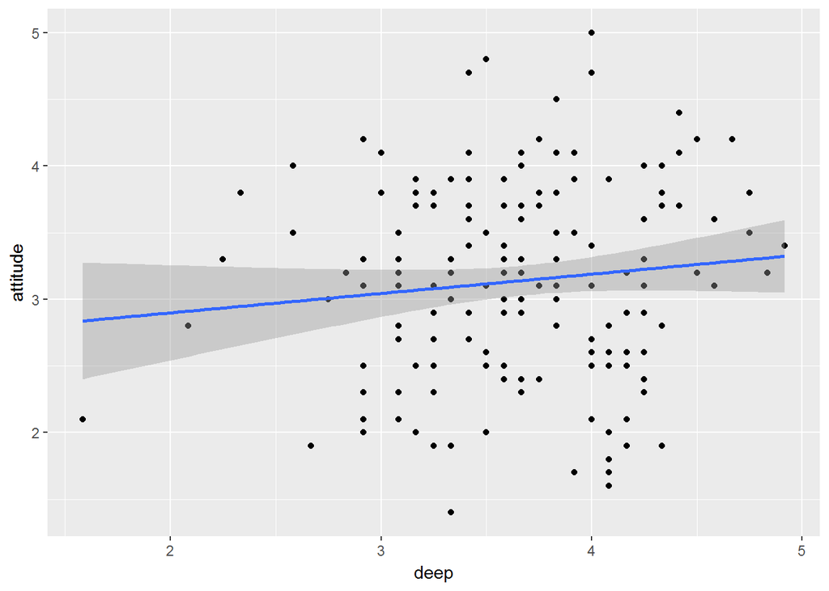

```
##
## Call:
## lm(formula = attitude ~ deep, data = learning2014)
##
## Residuals:
##      Min       1Q   Median       3Q      Max
## -1.69247 -0.55919  0.06358  0.51278  1.81072
##
## Coefficients:
##             Estimate Std. Error t value Pr(>|t|)
## (Intercept)   2.6084     0.3804   6.857 1.36e-10 ***
## deep          0.1452     0.1022   1.420    0.157
## ---
## Signif. codes:  0 '***' 0.001 '**' 0.01 '*' 0.05 '.' 0.1 ' ' 1
##
## Residual standard error: 0.7277 on 164 degrees of freedom
## Multiple R-squared:  0.01215,    Adjusted R-squared:  0.00613
## F-statistic: 2.018 on 1 and 164 DF,  p-value: 0.1574
```

The statistical test related to the parameters is a test for the null-hypothesis, that the beta-parameter in the regression model is actually zero. The p-value indicates the probability of that happening, using this statistical model. The influence of an explanatory variable is statistically significant, if it (in general) is <0,05. The highest value the p-value could take to be statistically at least somewhat significant, is 0,1.

In the above summary-tables, the p-values are for attitude 4.12e-09, which is extremely good, and strictly less than 0,001 which is the best of the signifigance levels. So the influence of attitude to points seems to be significant, and reading from the table, the first estimate, i.e. the beta-parameter, is 3,5255 which indicates a strong positive influence on points. So a good attitude correlates with good points, simply said. The p-value for deep is 0.897, which is not at all a good p-value - it is significantly greater than 0,1, so the influence of deep on points cannot be considered statistically significant. For stra, the p-value is 0.0603, which is pretty good - it is close to 0,05 and definitely less than 0,1.

Attempting to find variables that have statistically significant relationships with the points-variable, I tried many options, one of which was the combination of the variables ‘deep’, ‘stra’, and ‘surf’ as the explanatory variables, which gave puzzling results.

```
##
## Call:
## lm(formula = points ~ deep + stra + surf, data = learning2014)
##
## Residuals:
##      Min       1Q   Median       3Q      Max
## -15.1235  -3.0737   0.5226   4.2799  10.3229
##
## Coefficients:
##             Estimate Std. Error t value Pr(>|t|)
## (Intercept)  26.9143     5.1169   5.260  4.5e-07 ***
## deep         -0.7443     0.8662  -0.859   0.3915
## stra          0.9878     0.5962   1.657   0.0994 .
## surf         -1.6296     0.9153  -1.780   0.0769 .
## ---
## Signif. codes:  0 '***' 0.001 '**' 0.01 '*' 0.05 '.' 0.1 ' ' 1
##
## Residual standard error: 5.827 on 162 degrees of freedom
## Multiple R-squared:  0.04071,    Adjusted R-squared:  0.02295
## F-statistic: 2.292 on 3 and 162 DF,  p-value: 0.08016
```

Fitting the model, the beta-parameters could be read from the summary-table: for the variable deep the beta-parameter is -0,7443, stra 0,9878 and surf -1,6296. The p value for each of these is, however, greater than 0,05, and for deep the biggest of all. As 0,05 is considered to be the general, known limit for statistical signifigance, the variable deep cannot be considered as an influencing variable for exam points.

To reassign my model, I set the variables ‘attitude’, ‘stra’ and ‘surf’ as the explanatory variables.

```r
library(ggplot2)
library(GGally)
# create an plot matrix with ggpairs()
ggpairs(learning2014, lower = list(combo = wrap("facethist", bins = 20)))
```

[output not shown]

```r
# create a regression model with multiple explanatory variables
my_model4 <- lm(points ~ attitude + stra + surf, data = learning2014)

# print out a summary of the model
summary(my_model4)
```

```
##
## Call:
## lm(formula = points ~ attitude + stra + surf, data = learning2014)
##
## Residuals:
##      Min       1Q   Median       3Q      Max
## -17.1550  -3.4346   0.5156   3.6401  10.8952
##
## Coefficients:
##             Estimate Std. Error t value Pr(>|t|)
## (Intercept)  11.0171     3.6837   2.991  0.00322 **
## attitude      3.3952     0.5741   5.913 1.93e-08 ***
## stra          0.8531     0.5416   1.575  0.11716
## surf         -0.5861     0.8014  -0.731  0.46563
## ---
## Signif. codes:  0 '***' 0.001 '**' 0.01 '*' 0.05 '.' 0.1 ' ' 1
##
## Residual standard error: 5.296 on 162 degrees of freedom
## Multiple R-squared:  0.2074, Adjusted R-squared:  0.1927
## F-statistic: 14.13 on 3 and 162 DF,  p-value: 3.156e-08
```

The summary-table shows the beta-parameters for each of the aforementioned variables, and also that the p-value for ‘attitude’ is 0,0000000193 - which is by all means strictly less than 0,05! Now, with this model, at least for the attitude parameter, the probability of making a Type I -error (discarding error) is very little. For the other parameters, stra and surf, both have >0,1 p-values, which gives the results signifigance level to be quite low and the probability of making the Type I -error (of discaring the null hypothesis) slightly greater.

Fitting the model without the slightly problematic ‘surf’-variable, helps a little, as can be seen from the summary table below:

```
##
## Call:
## lm(formula = points ~ attitude + stra, data = learning2014)
##
## Residuals:
##      Min       1Q   Median       3Q      Max
## -17.6436  -3.3113   0.5575   3.7928  10.9295
##
## Coefficients:
##             Estimate Std. Error t value Pr(>|t|)
## (Intercept)   8.9729     2.3959   3.745  0.00025 ***
## attitude      3.4658     0.5652   6.132 6.31e-09 ***
## stra          0.9137     0.5345   1.709  0.08927 .
## ---
## Signif. codes:  0 '***' 0.001 '**' 0.01 '*' 0.05 '.' 0.1 ' ' 1
##
## Residual standard error: 5.289 on 163 degrees of freedom
## Multiple R-squared:  0.2048, Adjusted R-squared:  0.1951
## F-statistic: 20.99 on 2 and 163 DF,  p-value: 7.734e-09
```

### Interpreting the model parameters

R-squared is a statistical measure of how close the data are to the fitted regression line. It is also known as ‘the coefficient of determination’, or ‘the coefficient of multiple determination’ for multiple regression, as in this case. By definition, R-squared is the percentage of the response variable variation that is explained by a linear model. In other words: how well the model explains the main variables variation, as opposed to other factors that might affect the main variable. It can be written as

R-squared = Explained variation / total variation

R-squared is always between 0 and 100%: If R-squared is 0% that indicates the model explains none of the variability of the response data around its mean. If R-squared is 100% that indicates that the model explains all the variability of the response data around its mean.

### Graphical model validation

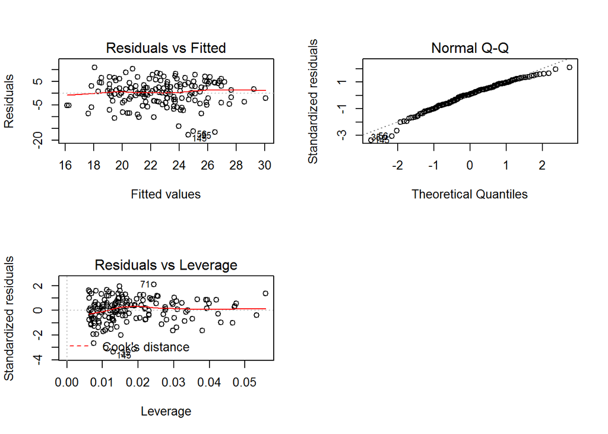

```r
# create a regression model with multiple explanatory variables
my_model4 <- lm(points ~ attitude + stra, data = learning2014)

# draw diagnostic plots using the plot() function. Choose the plots 1, 2 and 5
par(mfrow = c(2,2))
plot(my_model4, which=c(2,5,1))
```

In linear regression the assumptions include that the target variable is assumed to be a linear combination of the explanatory variables - i. e. the fisrt big assumption associated with a linear model is linearity. Generally, it is useful to assume also, that the errors are normally distributed and moreover, with a mean of 0 and a constant variance. This includes also the notion that the errors are not correlated and that the size of an error does not depend on the explanatory variables. There are a number of graphical ways to explore these assumptions, for example:

### The Residuals vs. Fitted values -plot

The Residuals vs. Fitted values -plot explores the constant variance assumption of the errors in the model, in other words the assumption that there should be no or close to none dependency between the errors and the explanatory variables. The simple plot shows residuals and model predictions, and if there seems to be any pattern in the plot, one could conclude that there is some dependency and the variance of the errors is not constant.

### The Residual vs. Leverage -plot

The Residueal vs. Leverage -plot measures, how much impact a signle observation has on the model. By analyzing the plot, any observations that have a high impact on the model, can be identified. The model of the two explanatory variables affecting the points-variable, we can see that the scale of the Leverage-plot is not very wide - only from 0 to 0,05. This indicates, that no observation is stranded outside the plot, and if there are observations in the fringes of the plot, the distance to other observations is not so big. Also, all the observations seem to fall in the plot quite evenly, which in itself indicates that there are no single observations having unusually high impact on the model. So the linearity assumption can be said to be correct in this model.